# Water level regulation

[NO_WLEV_001]

Author

Affiliation

Hanno Sandvik

Norwegian Institute for Nature Research

Published

October 8, 2025

**Status**

This indicator documentation is complete, and indicator values can be calculated as described below.

> **Recomended citation**: Sandvik, H. 2025. Water level regulation (ID: NO_WLEV_001) v. 001.000. ecRxiv: https://view.nina.no/ecRxiv/

> **Version**: 001.000

**Show metadata**

Table 1: Indicator metadata

| Indicator ID | NO_WLEV_001 |
| --- | --- |
| Indicator Name | Water level regulation |
| Country | Norway |
| Continent | Europe |
| Ecosystem Condition Typology Class | A1 - Physical State Characteristics |
| Realm | Freshwater (F) |
| Biome | F2 Lakes biome |
| Ecosystem | F2.4 Freeze-thaw lakes |
| Year added | 2025 |
| Last update | 2025 |
| status | complete |
| Version | 001.000 |
| Version comment | First complete version |
| url | https://github.com/NINAnor/ecRxiv/tree/main/indicators/NO_WLEV_001 |
| Normalised | Yes |
| Spatial aggregation pathway | Scale - Transform - Aggregate (area-weighted arithmetic mean) - Truncate |

**Logg**

- 15 May 2025 - Version 001.000 started: first complete version
- 24 Sep 2025 - Version 001.000 submitted to review
- 08 Oct 2025 - Version 001.000 revised and ready for publication

## 1. Summary

Lake ecosystems are negatively affected by anthropogenic activities that lead to variation in water level, such as emptying and refilling lakes that have been dammed (reservoirs), e.g. for hydroelectric power production. Such anthropogenic water level variation negatively affects macrophytes and invertebrates as well as the fish fauna of the reservoirs.

The indicator *water level regulation* attempts to capture the impact of anthropogenic water level variation on lake fish fauna. This impact is mediated by effects of water level regulation on prey species as well as the accessibility of spawning habitat.

The steps in estimating indicator values can be summarised as follows:

- Downloading public information on the lowest and highest regulated water level of Norwegian reservoirs.
- Calculating regulation height as the difference between the highest and lowest regulated water level.
- Estimating missing values of regulation height based on reservoir area and dammed volume, where available.
- Inferring remaining missing values based on the distribution of known regulation heights.
- Using a re-sampling procedure to estimate prediction intervals.
- Scaling and transforming measurements to “modified Ecological Quality Ratios” according to the normative definitions for “ecological status” categories provided by the Water Framework Directive.
- Aggregating estimates geographically using area-weighted averages.
- Truncating the values obtained to the interval from 0 to 1.

### Interpretation

> An indicator value of 1 signifies a condition where there is little or no human impact on the water body. Values decreasing toward zero reflect negative ecological change, specifically a larger (impact of) water level variation due to lake regulation.

## 2. About the underlying data

The underlying data come from two datasets maintained by the Norwegian Water Resources and Energy Directorate ([NVE](https://www.nve.no/)). One is the *Innsjødatabase* (“lake database”), containing information (such as location, area and altitude) on the more than 260,000 Norwegian lakes with an area of at least 2500 m². The *Magasin* dataset contains technical information (such as regulated water level, type and age) on the subset of lakes that are reservoirs.

### 2.1 Spatial and temporal resolution and extent

The **spatial** resolution is on the level of individual lakes. The **temporal** resolution, i.e. the update frequency of the datasets, is daily.

### 2.2 Sampling design

The NVE datasets are sampled exhaustively, in the sense that all lakes that fulfil the defining criteria are included (an area of at least 2500 m² for the *Innsjødatabase*; water level regulation for the reservoir dataset). In the case of the reservoir dataset, however, there are many missing values for regulation height. This may introduce a certain sampling bias of unknown sign and magnitude.

### 2.3 Original units

Water level regulation is expressed as the regulation height of the water level of a reservoir, measured in metres. “Regulation height” (Norw. *reguleringshøyde*) is the difference between the highest regulated water level and the lowest regulated water level, which are both measured in metres above sea level.

### 2.4 Instructions for citing, using and accessing data

For suggestions on how to cite the datasets, see *Innsjødatabase* and *Magasin*. The data used are publicly available but not machine-readable. They need to be downloaded manually from https://nedlasting.nve.no/gis/. For further details, see chapter 7 below.

## 3. Indicator properties

Water level regulation has the ID **79** in the metadata table for ecological condition variables for use in Norway (Czúcz et al. 2023).

As such, the water level regulation of lakes is a pressure variable, not an ecosystem condition variable. However, some attempts to measure the ecological effect of water level regulation have been made (DGVF 2025). Known effects on invertebrates are summarised in DGVF (2025, table 6.20), although merely qualitatively, or in terms of tolerance thresholds. Based on observed effects on macrophytes, Mjelde et al. (2013, Hellsten & Mjelde 2009; tables 4.7 and V4.2.7 in DGVF 2025) have designed the WIc indicator, which, however, so far lacks important reference values and has far too few datapoints in Norway to allow an estimation of indicator values. Finally, DGVF (2025, table 6.19) defines “indicative” reference levels for an index that is based on average responses of the lake fish community to water level regulation. In the absence of any better alternative, the latter index is used here.

### 3.1 Ecosystem Condition Typology Class (ECT)

The ECT of water level regulation is **A1** (physical state) because the indicator measures the physical modification of the lake level.

**B1** (compositional state) may be regarded as a *secondary* ECT class of water level regulation, as the index is expressed in terms of the average effect of water level regulation on the fish fauna present, which is a measure of *biodiversity*.

#### 3.1.1 Other condition typologies

In the Norwegian classification of ecological characteristics (*økologiske egenskaper*) according to Nybø & Evju (2017, p. 35), the indicator represents **abiotic conditions** (*abiotiske forhold*).

Among the *quality elements* distinguished in the Water Framework Directive, the indicator belongs to the *supporting hydromorphological elements*, representing **lake depth variation** (WFD, Annex V).

### 3.2 Ecosystem condition characteristic

Intact lakes are characterised by having no or little water level variation (rarely more than a few centimetres), and water level regulation represents a physical alteration of lakes. The fish community responds to water level regulation because important prey taxa are absent and/or because spawning habitats become inaccessible when the water level variation is too high.

### 3.3 Collinearities with other indicators

No known collinearities with other ecosystem condition indicators exist.

### 3.4 Impact factors

Water level regulation represents a physical alteration of lakes.

### 3.5 Spatial aggregation

Spatial aggregation is here carried out after scaling and transformation but before truncation. The aggregation pathway thus largely follows Sandvik (2019, 2025) and consists of the following steps:

1. *Scaling.* The raw variable values are linearly scaled so that X<sub>0</sub> becomes 0 and X<sub>100</sub> becomes 1. Note that the resulting values may be negative (if X is poorer than X<sub>0</sub>).
2. *Transformation.* The scaled values are transformed in a stepwise-linear manner in accordance with the reference levels. The resulting values are here referred to as **mEQR**s (“modified Ecological Quality Ratios”). This step requires an adjustment when values of X are much higher than X<sub>0</sub>; the approach chosen here ensures that no indicator value can be below −0.2 (described, in Norwegian, [here](https://github.com/NINAnor/WFD2ECA/blob/main/forklar/asympEQR.md)).
3. *Aggregration.* The mEQR values are spatially aggregated using area-weighted arithmetic averages.
4. *Truncation.* When the aggregated values are truncated (if necessary) to the interval from 0 to 1 in a final step, they become indicator values sensu SEEA EA.

## 4. Reference condition and levels

### 4.1 Reference condition

The *Water Framework Directive* (hereafter **WFD**) defines the reference condition of a water body as “the condition of a quality element where there is little or no human impact on the water body. The reference condition is therefore also referred to as the natural condition” (DGVF 2025).

### 4.2 Reference levels

According to the WFD, reference levels are defined for X<sub>0</sub>, X<sub>20</sub>, X<sub>40</sub>, X<sub>60</sub>, X<sub>80</sub>, and X<sub>100</sub>. These are used to classify the “ecological status” of water bodies as “bad” (X<sub>0</sub> ≤ X ≤ X<sub>20</sub>), “poor” (X<sub>20</sub> < X ≤ X<sub>40</sub>), “moderate” (X<sub>40</sub> < X ≤ X<sub>60</sub>), “good” (X<sub>60</sub> < X ≤ X<sub>80</sub>), and “high” (X<sub>80</sub> < X ≤ X<sub>100</sub>). The WFD (Annex V, section 1.2) provides the following normative definition of “high status”: “The values of the biological quality elements for the surface water body reflect those normally associated with that type under undisturbed conditions, and show no, or only very minor, evidence of distortion.”

Reference levels for water level regulation (more specific, its effects on the fish fauna) are provided in table 6.19 of DGVF (2025) as follows: X<sub>80</sub> = 1 m, X<sub>60</sub> = 5 m, X<sub>40</sub> = 8 m, and X<sub>20</sub> = 12 m. The table does not specify values for X<sub>100</sub> (which can be assumed to be 0, i.e. the absence of water level regulation) and X<sub>0</sub> (which is here arbitrarily defined as twice the value of X<sub>20</sub>).

```r
klassegrenser <- c(Pess = 240,
                   X0   =  24,
                   X20  =  12,
                   X40  =   8,
                   X60  =   5,
                   X80  =   1,
                   X100 =   0,
                   Opt  =   0)
```

#### 4.2.1 Spatial resolution and validity

The spatial resolution of WFD reference levels is the water body (i.e. lake). Currently, reference levels of water level regulation do not differ between lake water body types.

## 5. Uncertainties

### 5.1 General uncertainties

The reference levels are still stated to be “indicative” (DGVF 2025), and it is unknown how representative they are of different lake types (e.g. mountain lakes vs. lowland lakes). No attempt is made to quantify this kind of uncertainty.

### 5.2 Reported uncertainties

The uncertainties reported are inferential, i.e. they refer to the uncertainty around the point estimates. The dataset on water levels used here has almost 50% missing values. The procedure described below estimates the unknown values based on the distribution of the known values, and quantifies the uncertainty attached to these inferences using simulations (resampling).

## 6. References

Czúcz B, Sandvik H, Framstad E & Schartau AK. 2023. Metadata for ecological condition variables for use in Norway, version 1.0. [[doi:10.5281/zenodo.10187828](https://doi.org/10.5281/zenodo.10187828)]

DGVF [Direktoratsgruppa for vannforvaltning]. 2025. *Veileder for klassifisering av miljøtilstand i kyst- og ferskvann* [version of 28 Jan 2025]. Vannportalen. https://www.vannportalen.no/veiledere/klassifiseringsveileder/

Hellsten S & Mjelde M. 2009. Macrophyte responses to water level fluctuation in Fennoscandinavian lakes – applying a common index. *Verh Int Ver Limnol* **30**: 765–769. [[doi:10.1080/03680770.2009.11902235](https://doi.org/10.1080/03680770.2009.11902235)]

Mjelde M, Hellsten S & Ecke F. 2013. A water level drawdown index for aquatic macrophytes in Nordic lakes. *Hydrobiologia* **704**: 141–151. [[doi:10.1007/s10750-012-1323-6](https://doi.org/10.1007/s10750-012-1323-6)]

NVE [Norges vassdrags- og energidirektorat]. 2025. *Innsjødatabase*. https://www.nve.no/kart/kartdata/vassdragsdata/innsjoedatabase/ (description) and https://nedlasting.nve.no/gis/ (download)

NVE [Norges vassdrags- og energidirektorat]. 2025. *Vannkraft: Magasin*. https://objektkatalog.geonorge.no/Pakke/Index/EAPK_88F1053F_8EE5_437b_859C_CF6EFB0B945A (metadata) and https://nedlasting.nve.no/gis/ (download)

Nybø S & Evju M (eds). 2017. *Fagsystem for fastsetting av god økologisk tilstand. Forslag fra et ekspertråd.* Klima- og miljødepartementet, Oslo. https://www.regjeringen.no/id2558481/

Sandvik H. 2019. Ferskvann i vannforskriften og naturindeksen. Forslag til samordning og dataflyt. *NINA Rapp* **1723**: 1–38. [[hdl:11250/2631056](http://hdl.handle.net/11250/2631056)]

Sandvik H. 2025. WFD2ECA: Dataflyt fra vannforskriften til økologisk tilstandsregnskap og naturindeks, version 2.0. https://github.com/NINAnor/WFD2ECA [[doi:10.5281/zenodo.10278000](https://doi.org/10.5281/zenodo.10278000)]

**SEEA EA**: United Nations et al. 2024. *System of Environmental-Economic Accounting – Ecosystem Accounting.* UN, New York. https://seea.un.org/ecosystem-accounting

**WFD**: EU. 2000. Directive 2000/60/EC of the European Parliament and of the Council of 23 October 2000 establishing a framework for Community action in the field of water policy. *Off J EU L* **43** (327): 1–72. [[CELEX:32000L0060](http://eur-lex.europa.eu/LexUriServ/LexUriServ.do?uri=CELEX:32000L0060:en:NOT)]

## 7. Import and prepare datasets

### 7.1 WFD2ECA

The dataflow described here uses some functions and data files from the GitHub repository [WFD2ECA](https://github.com/NINAnor/WFD2ECA/) (Sandvik 2025). We start by downloading them from archived version 2.0 of that repo.

```r
vannkategori <- "L"

if (!file.exists("../data/NVE.RData")) {
  download.file("https://zenodo.org/records/16811526/files/NINAnor/WFD2ECA-v2.0.zip",
                "../data/WFD2ECA.zip")
  folder <- "../data/WFD2ECA"
  unzip("../data/WFD2ECA.zip", exdir = folder)
  while (length(list.files(folder)) == 1) {
    folder <- paste0(folder, "/", list.files(folder))
  }
  whichDataFile <- c(
    "navnNVEl.csv",
    "Norge.map",
    "NVE.RData"
  )
  dummy <- file.copy(from = paste0(folder, "/data/", whichDataFile),
                     to   = "../data/",
                     overwrite = FALSE)
  dummy <- file.copy(from = list.files(paste0(folder, "/R/"), full.names = TRUE),
                     to   = ".",
                     overwrite = FALSE)
  dummy <- file.remove("../data/WFD2ECA.zip")
  unlink("../data/WFD2ECA", recursive = TRUE)
}
```

Next, we load the functions contained in that repo.

```r
source("Funksjon.R")
for (filnavn in list.files(".", full.names = TRUE)) {
  if (substr(filnavn, nchar(filnavn), nchar(filnavn)) %=% "R") {
    source(filnavn)
  }
}
```

### 7.2 Innsjødatabase

Detailed information on Norwegian lakes is available from the *Innsjødatabase* (“lake database”) maintained by the Norwegian Water Resources and Energy Directorate ([NVE](https://www.nve.no/)). This dataset is publicly available, but it needs to be downloaded manually:

- Navigate to https://nedlasting.nve.no/gis/.
- Choose (or retain) “Vektordata” in the “Velg datatype” dropdown menu.
- Expand the “Innsjø” heading.
- Tick the “Innsjø” box.
- Click “Neste”.
- Choose “ESRI shapefil (.shp)” in the “Velg kartformat” dropdown menu.
- Choose “Geografiske koordinater ETRS89” in the “Velg koordinatsystem” dropdown menu.
- Choose “Overlapper” in the “Velg utvalgsmetode” dropdown menu.
- Choose “Landsdekkende” in the “Velg dekningsområde” dropdown menu.
- Click “Neste”.
- Provide your e-mail address in the “E-post” boxes.
- Tick the “Jeg har lest og forstått betingelser…” box to accept the terms of use.
- Upon pressing “Send”, a link to a compressed archive (zip) will be sent to your e-mail.
- Click that link to download the data.
- Uncompress the zip archive. (Upon uncompression, the relevant files are located in the folder `NVEKartdata\NVEData\Innsjo`.)
- Place the shapefiles (called `Innsjo_Innsjo.*`) in the “data” folder.

(The analyses use a cached version called “NVE.RData”, which is available via the WFD2ECA repo, see section 7.1.)

With the necessary files in place, we can read the export from *Innsjødatabase*.

```r
nve <- lesInnsjodatabasen("Innsjo_Innsjo.dbf")
```

```
OBS: For 3 innsjøer var høyden over havet angitt å være negativ.
     Disse ble satt til <NA>.

OBS: For 4 innsjøer var det norske arealet angitt å være negativ.
     Disse ble satt til <NA>.

OBS: For 1 innsjøer var tilsigsfeltet angitt å være negativ. Disse
     ble satt til <NA>.

OBS: For 589 innsjøer var deres tilsigsfelt angitt å være mindre
     enn deres areal. For disse ble tilsigsfeltet satt til
     arealet.

Innlesing av innsjødatabasen var vellykka og omfatta 267193
innsjøer. (Men legg merke til beskjedene over!)
```

The output informs us of a few adjustments made to the data, but that the operation was successful. This is how the dataset looks like:

```r
head(nve)
```

```
     lnr  nam   reg mnr  hoh  areal arealn tilsig vassdrag omrade lat lon
1 101659 <NA> FALSE  NA   NA 0.0100   0.01   0.08  119.62B    119  NA  NA
2 143542 <NA> FALSE  NA   NA 0.0100   0.01   0.05    116.B    116  NA  NA
3 142928 <NA> FALSE  NA   NA 0.0025   0.00   0.06   117.2Z    117  NA  NA
4  66236 <NA> FALSE  NA 1284 0.0200   0.02   1.09  073.C42    073  NA  NA
5 149735 <NA> FALSE  NA 1381 0.0025   0.00   0.86  073.C41    073  NA  NA
6  43611 <NA> FALSE  NA  741 0.0200   0.02   2.52  144.D1B    144  NA  NA
```

An explanation of the columns (in Norwegian) is given [elsewhere](https://github.com/NINAnor/WFD2ECA/blob/main/forklar/lesInnsjodatabasen.md#funksjonsverdi).

### 7.3 Reservoir dataset

The second dataset is available from the same source as the previous one, and the procedure to access it is analogous:

- Navigate to https://nedlasting.nve.no/gis/.
- Choose (or retain) “Vektordata” in the “Velg datatype” dropdown menu.
- Expand the “Vannkraft” heading.
- Tick the “Magasin” box.
- … (follow the 5th to 14th bullet point above) …
- Uncompress the zip archive. (Upon uncompression, the relevant files are located in the folder `NVEKartdata\NVEData\Vannkraft`.)
- Place the shapefiles (called `Vannkraft_Magasin.*`) in the “data” folder.

Likewise, we read the data about water reservoirs and define a column for regulation height.

```r
mag <- read_sf("../data/Vannkraft_Magasin.shp")
geo <- mag$geometry
mag <- as.data.frame(mag)[, -25]
mag$lat <- mag$long <- NA
for (i in 1:nrow(mag)) {
  mag$lat[i]  <- mean(geo[[i]][[1]][[1]][, 2])
  mag$long[i] <- mean(geo[[i]][[1]][[1]][, 1])
}
mag$lrv_moh[which(mag$lrv_moh < 0)] <- NA
mag$regh <- mag$hrv_moh - mag$lrv_moh
```

This is how the dataset looks like:

```r
head(mag)
```

```
         objType vatnLnr magasinNr       magNavn kategori lrv_moh hrv_moh
1 InnsjøRegulert     242       811  MYKLEBYSJØEN        1   985.5  988.75
2 InnsjøRegulert    5360      2330  Dammyrdammen        2      NA      NA
3 InnsjøRegulert  205541      2331 Solbergdammen        2      NA      NA
4 InnsjøRegulert   26289      2412     Dalatjømi        2      NA      NA
5 InnsjøRegulert    6383      1183  FINNVOLLVATN        2      NA      NA
6 InnsjøRegulert    6426      1186    BUSTULVATN        1   556.5  560.00
  status idriftAar kdbNr konsStatus kStatDato  spID        formal_L areal_km2
1      D      1915    NA         NA      <NA> 00495 Kraftproduksjon      2.37
2      D      1905    NA         NA      <NA>  <NA> Kraftproduksjon      0.26
3      D      2012    NA         NA      <NA> 04201 Kraftproduksjon      0.01
4      D      2015    NA         NA      <NA>  <NA> Kraftproduksjon      0.03
5      D      1800    NA         NA      <NA> 07809 Kraftproduksjon      0.19
6      D      1800    NA         NA      <NA> 07806 Kraftproduksjon      0.51
  volOppdemt delfeltNr vannkrvNr   vkrvNavn vassdragNr
```

[output cut: 20 more lines]

An explanation of the columns (in Norwegian) is given on [Geonorge](https://objektkatalog.geonorge.no/Objekttype/Index/EAID_7A22ADFE_946D_4f75_B12D_4993A37B2183) and in this pdf (p. 4).

## 8. Spatial units

Data (measurements) are representative for their respective lakes, which correspond to Ecosystem Assets. The Ecosystem Accounting Area covered by the data is mainland Norway.

## 9. Analyses

### 9.1 Inspection of the dataset

We can now have an initial look at the data in terms of a map …

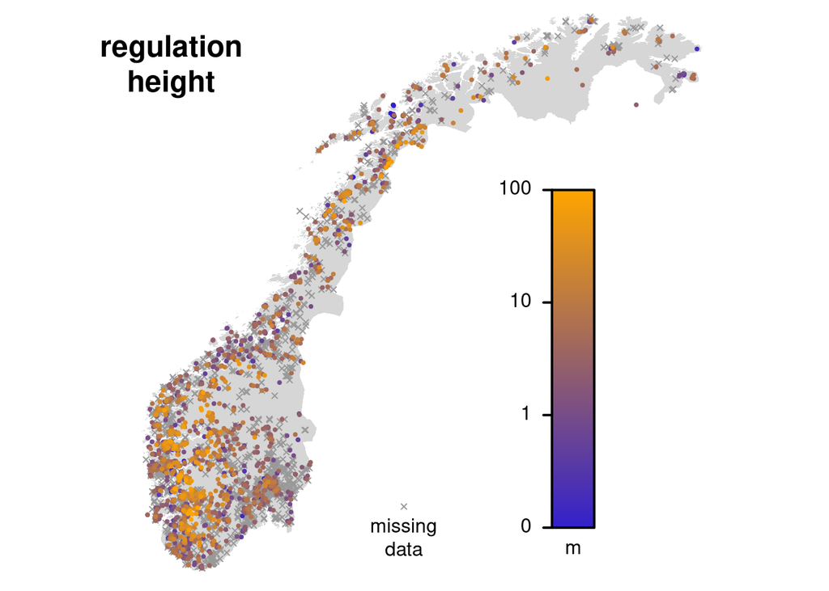

Map of Norway with points for all reservoirs. Colours indicate unscaled variable values.

```r
{
  xaxis <- seq(-1, 2, 1)
  dig <- 0
  snudd <- TRUE

  ml <- mag
  ml$maaling <- lg(ml$regh)
#  ml$maaling[which(ml$maaling < -1)] <- -1
#  ml$maaling[which(ml$maaling > +2)] <- +2
  if (snudd) xaxis <- rev(xaxis)
  xlim <- range(xaxis)
  ml$maaling <- sapply(sapply(ml$maaling, max, xlim[1]), min, xlim[2])
  ml <- ml[order(ml$maaling, decreasing = !snudd), ]
  missing <- ml[ which(is.na(ml$maaling)), ]
  ml      <- ml[-which(is.na(ml$maaling)), ]

  load("../data/Norge.map")
  par(mai = rep(0, 4))
  plot(Norge.kontur, xlim = c(3.5, 31.5), ylim = c(57.5, 71.5),
       xaxs = "i", yaxs = "i", asp = 2, col = grey(0.84), border = NA)
  points(missing$long, missing$lat, pch = 4, cex = 0.6, col = grey(0.6))
  points(ml$long, ml$lat, pch = 20, cex = 0.6, col = if (snudd)
         farve(ml$maaling, xlim[2], xlim[1]) else
         farve(ml$maaling, xlim[1], xlim[2]))
  text(6, 70, "regulation\nheight", cex = 1.5, font = 2)
  for (i in seq(0, 0.999, 0.001)) {
    rect(24, 59+i*8, 26, 59+(i+0.001)*8, border = NA,
         col = if (snudd) farve(i, 1, 0) else farve(i, 0, 1))
  }
  rect(24, 59, 26, 67, lwd = 2)
  for (i in xaxis) {
    lines(c(24.0,23.6), rep(59 + 8 * (i-xlim[1]) / (xlim[2]-xlim[1]), 2), lwd=2)
  }
  text(23.6, 59 + 8 * (xaxis - xlim[1]) / (xlim[2] - xlim[1]),
       rev(c(0, 1, 10, 100)), pos = 2)
  text(25, 58.5, "m")
  points(17, 59.5, pch = 4, cex = 0.6, col = grey(0.6))
  text(17, 59.0, "missing")
  text(17, 58.5, "data")
}
```

… and a summary table.

```r
{
  cat("Data points in the regulation dataset: " %+% nrow(mag) %+%
      " reservoirs\n\nSummary of regulation heights in metres:\n")
  print(summary(mag$regh))
}
```

```
Data points in the regulation dataset: 2929 reservoirs

Summary of regulation heights in metres:
   Min. 1st Qu.  Median    Mean 3rd Qu.    Max.    NA's
   0.00    2.00    4.85   11.06   13.00  140.00    1460
```

The median regulation height is almost 5 metres, the maximum more than 100 metres. Unfortunately, there are many missing values. We will have to simulate them based on the data that are available.

### 9.2 Simulating regulation heights

To do so, we first need to look at the difference between hydropower reservoirs and other ones.

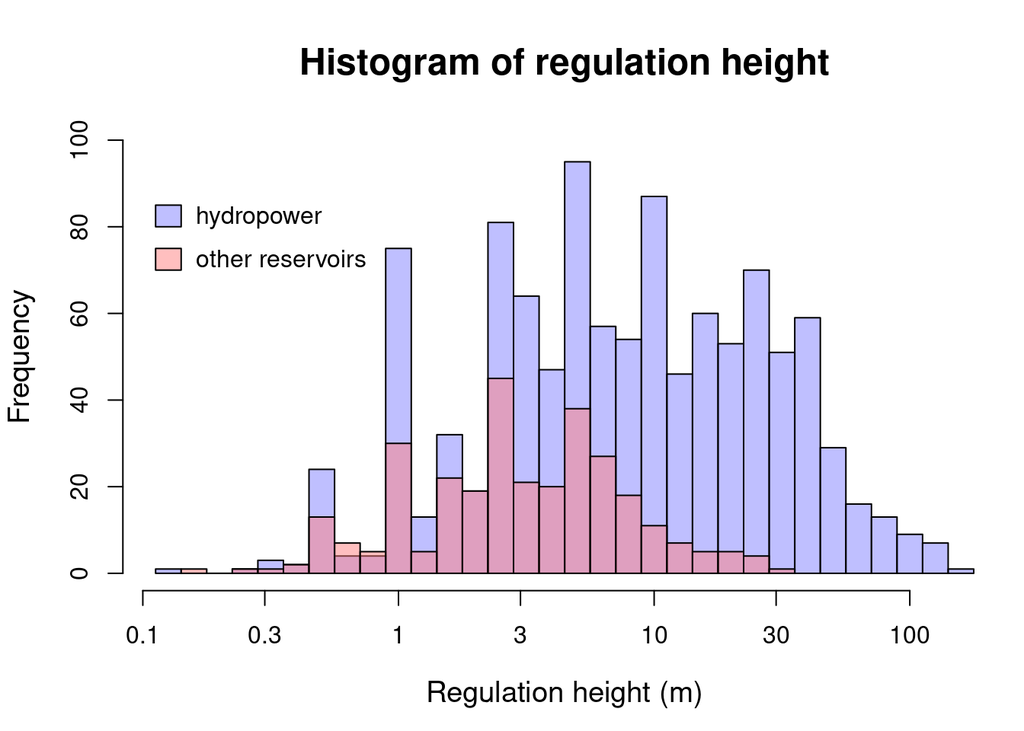

Water level regulation heights differ between hydropower and other reservoirs.  
(Note that the x-axis is logarithmic.)

```r
mag$power <- mag$formal_L == "Kraftproduksjon"
w0 <- which(!mag$power & mag$status == "D")
w1 <- which( mag$power & mag$status == "D")

par(mai = c(0.96, 0.84, 0.84, 0.12))
hist(lg(mag$regh[w1]), breaks = 25, col = rgb(0.5, 0.5, 1, 0.5),
     ylim = c(0, 100), xaxt = "n", xlab = "Regulation height (m)",
     main = "Histogram of regulation height",
     cex.main = 1.5, cex.lab = 1.2)
hist(lg(mag$regh[w0]), breaks = 25, col = rgb(1, 0.5, 0.5, 0.5), add = TRUE)
xp <- c(0.1, 0.3, 1, 3, 10, 30, 100)
axis(1, lg(xp) - 0.05, xp)

rect(-1, 80, -0.9, 85, col = rgb(0.5, 0.5, 1, 0.5))
rect(-1, 70, -0.9, 75, col = rgb(1, 0.5, 0.5, 0.5))
text(-0.9, 82, "hydropower", pos = 4)
text(-0.9, 72, "other reservoirs", pos = 4)
```

Unknown regulation heights can be simulated by drawing values at random from the known distributions. The figure shows that simulations will have to be done separately for hydropower and other reservoirs.

Some unknown regulation heights may be estimable with somewhat more accuracy, however. This can be achieved by approximating unknown regulation heights based on known reservoir volumes and reservoir areas. The relationship between the two is noisy but clear.

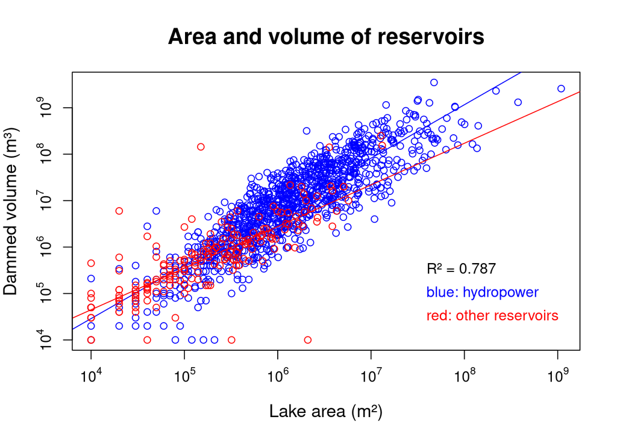

Lake area and dammed volume of reservoirs are clearly related, allowing a prediction of unknown regulation heights.  
(Note that both axes are logarithmic.)

```r
mod0 <- lm(lg(volOppdemt) ~ lg(areal_km2) * power, data = mag,
           subset = volOppdemt > 0 & areal_km2 > 0 & status == "D")

plot(lg(mag$areal_km2[c(w0, w1)]), lg(mag$volOppdemt[c(w0, w1)]),
     xaxt = "n", yaxt = "n", type = "n",
     xlab = "Lake area (m²)", ylab = "Dammed volume (m³)",
     main = "Area and volume of reservoirs",
     cex.main = 1.5, cex.lab = 1.2)
points(lg(mag$areal_km2[w1]),       lg(mag$volOppdemt[w1]),      col = "blue")
abline(mod0$coef[1] + mod0$coef[3], mod0$coef[2] + mod0$coef[4], col = "blue")
points(lg(mag$areal_km2[w0]),       lg(mag$volOppdemt[w0]),      col = "red")
abline(mod0$coef[1],                mod0$coef[2],                col = "red")
akser <- c(expression(10^4), expression(10^5), expression(10^6),
           expression(10^7), expression(10^8), expression(10^9))
axis(1, seq(-2, 3, 1), akser)
axis(2, seq(-2, 3, 1), akser)
text(1.5, -0.5, "R² = " %+% round(summary(mod0)$r.sq, 3), pos = 4)
text(1.5, -1.0, "blue: hydropower",      pos = 4, col = "blue")
text(1.5, -1.5, "red: other reservoirs", pos = 4, col = "red")
```

From this relationship we can predict regulation heights for quite some reservoirs. The predicted values are well correlated with the actual ones (only regarding lakes where the latter are known).

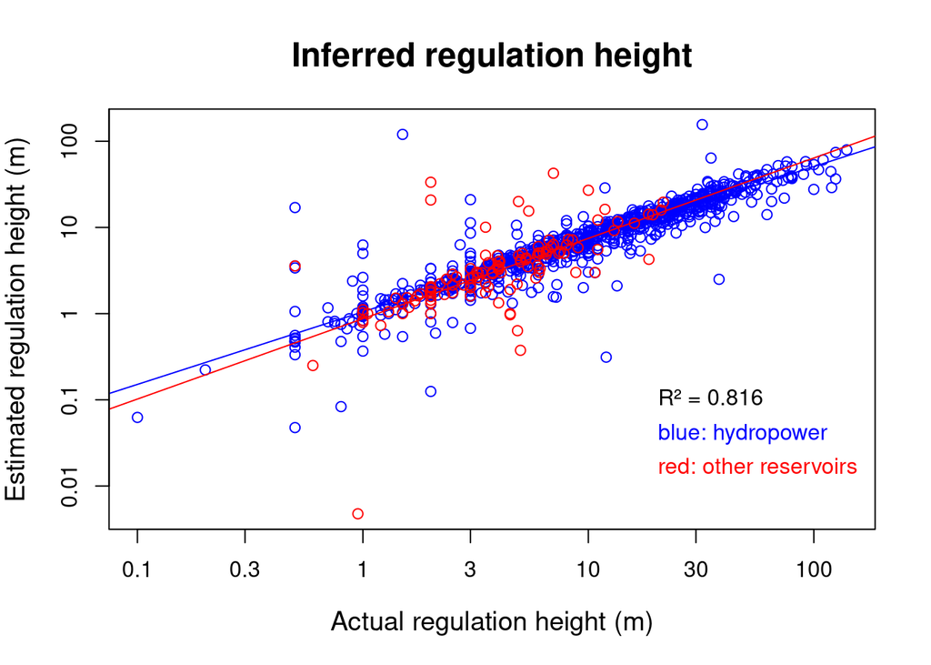

When regulation height is predicted from reservoir area and volume, the predicted values are well correlated with actual ones. (Note that both axes are logarithmic.)

```r
mag$logh <- lg(mag$regh)
mag$esth <- lg(mag$volOppdemt / sapply(mag$areal_km2, max, 0.0025))
mag$esth[which(is.infinite(mag$esth))] <- NA

mod1 <- lm(logh ~ esth * power, data = mag, subset = regh > 0 & status == "D")
mod2 <- lm(esth ~ logh * power, data = mag, subset = regh > 0 & status == "D")

w <- which(mag$status == "D" & !is.na(mag$regh) & is.finite(mag$logh))
plot(mag$logh[w], mag$esth[w],
     xaxt = "n", yaxt = "n", type = "n",
     xlab = "Actual regulation height (m)",
     ylab = "Estimated regulation height (m)",
     main = "Inferred regulation height",
     cex.main = 1.5, cex.lab = 1.2)
points(mag$logh[w1], mag$esth[w1], col="blue")
abline(mod2$coef[1] + mod2$coef[3], mod2$coef[2] + mod2$coef[4], col="blue")
points(mag$logh[w0], mag$esth[w0], col="red")
abline(mod2$coef[1]               , mod2$coef[2]               , col="red")
axis(1, lg(xp), xp)
axis(2, seq(-2, 3, 1), 10^seq(-2, 3, 1))
text(1.25, -1.0, "R² = " %+% round(summary(mod2)$r.sq, 3), pos = 4)
text(1.25, -1.4, "blue: hydropower",      pos = 4, col = "blue")
text(1.25, -1.8, "red: other reservoirs", pos = 4, col = "red")
```

Now we can run 1000 simulations for each reservoir. Regulation heights are calculated, inferred or estimated as follows:

- If the upper and lower regulation levels are reported in the NVE dataset, regulation height is simply the difference between the two.
- Otherwise, and if lake area and dammed volume are reported in the NVE dataset, 1000 random numbers are produced based on the prediction interval of the model explaining regulation height as volume divided by area (separately for hydropower and other reservoirs, and constraining regulation heights upwards to the upper limit of the actual distribution within these two categories).
- If none of the above is known, regulation height is drawn 1000 times at random from the actual distribution of known regulation heights (separately for hydropower and other reservoirs).

Furthermore, each reservoir is coupled to the respective lake entry in NVE’s lake database. This adds precise knowledge of the areas of all lakes and reservoirs.

```r
nsim <- 1000
# The values tabulated in the "Results" section were obtained using nsim = 10000

nve$drift <- 0
nve$regh  <- 0
regh <- matrix(0, nrow(nve), nsim, dimnames = list(nve$lnr, "sim" %+% 1:nsim))
samplePower <- mag$regh[which(!is.na(mag$regh) & mag$status == "D" &  mag$power)]
sampleOther <- mag$regh[which(!is.na(mag$regh) & mag$status == "D" & !mag$power)]
set.seed(144)

for (i in 1:nrow(mag)) {
  # couple records using NVE's reservoir number
  w <- which(nve$mnr == mag$magasinNr[i])
  if (!length(w)) {
    # couple records using NVE's lake identifier
    w <- which(nve$lnr == mag$vatnLnr[i])
  }
  if (length(w) > 1) {
    for (j in length(w):1) {
      # if more than one hit, remove the one with the wrong water region number
      if (!(mag$vassdragNr[i] %inneholder% nve$omrade[w[j]])) {
        w <- w[-j]
      }
    }
  }
  if (length(w) > 1) {
    for (j in length(w):1) {
      # if still more than one hit, use lake identifier rather than reservoir number
      if (mag$vatnLnr[i] %!=% nve$lnr[w[j]]) {
        w <- w[-j]
      }
    }
  }
  if (length(w) %=% 1 &
      mag$status[i] == "D") {
    nve$drift[w] <- mag$idriftAar[i]
    if (is.na(mag$regh[i])) {
      SAMPL <- if (mag$power[i]) samplePower else sampleOther
      if (is.na(mag$esth[i])) {
        # resample the known regulation heights if no other data are available
        nve$regh[w] <-  max(median(SAMPL), 0.01)
        regh[w, ] <- sapply(sample(SAMPL, nsim, TRUE), max, 0.01)
      } else {
        # infer regulation height from reservoir area and volume
        pred <- predict(mod1, data.frame(esth = mag$esth[i], power = mag$power[i]),
                        interval = "prediction", level = 0.95)[1, ]
        nve$regh[w] <- max(min(10^pred[["fit"]], max(SAMPL)), 0.01)
        pred <- pred[["fit"]] +
          rt(nsim, mod1$df) * (pred[["upr"]] - pred[["fit"]]) / qt(0.975, mod1$df)
        pred <- sapply(10^pred, min, max(SAMPL))
        regh[w, ] <- sapply(round(pred, 1), max, 0.01)
      }
    } else {
      # use precise regulation height if it is known
      regh[w, ] <- rep(max(0.01, mag$regh[i]), nsim)
      nve$regh[w] <-   max(0.01, mag$regh[i])
    }
  }
}

{# summarise results
  NumbL <- nrow(nve)
  AreaL <- sum(nve$areal, na.rm = TRUE)
  NumbR <- length(which(nve$regh > 0))
  AreaR <- sum(nve$areal[which(nve$regh > 0)], na.rm = TRUE)
  Q <- quantile(apply(regh, 2, weighted.mean, nve$areal, na.rm = TRUE),
                c(0.25, 0.50, 0.75))

  skriv("Summary:")
  skriv("Norway has ",
        NumbR, " dammed reservoirs. This amounts to ",
        formatC(100 * NumbR / NumbL, form = "f", dig = 1), "% of Norway's ",
        NumbL, "_lakes (disregarding ones that are smaller than 2500_m²).",
        pre = "* ", Bredde = 84)
  skriv("These reservoirs have a cumulative area of ",
        round(AreaR), "_km². This amounts to ",
        formatC(100 * AreaR / AreaL, form = "f", dig = 1),
        "% of the lake-covered area of Norway (which is ",
        round(AreaL), "_km²).", pre = "* ", Bredde = 84)
  skriv("The area-weighted average regulation height across Norwegian lakes, ",
        "including unregulated ones, amounts to approximately ",
        formatC(Q[2], form = "f", dig = 2), "_m. ",
        "This estimate has an interquartile range from ",
        formatC(Q[1], form = "f", dig = 2), "_m to ",
        formatC(Q[3], form = "f", dig = 2), "_m ",
        "(being a measure of its uncertainty).", pre = "* ", Bredde = 84)
}
```

```
Summary:
* Norway has 2375 dammed reservoirs. This amounts to 0.9% of Norway's 267193 lakes
  (disregarding ones that are smaller than 2500 m²).
* These reservoirs have a cumulative area of 6361 km². This amounts to 34.1% of the
  lake-covered area of Norway (which is 18676 km²).
* The area-weighted average regulation height across Norwegian lakes, including
  unregulated ones, amounts to approximately 5.35 m. This estimate has an
  interquartile range from 5.29 m to 5.42 m (being a measure of its uncertainty).
```

We define a new variable for the region of Norway (*landsdel*) in which the reservoir is situated. This is inferred from the ID number of the respective water region (*vannområde*).

```r
# Defining a column for the region of Norway,
# based on the water region ("vannområde")
nve$ldel <- NA
omr <- as.numeric(nve$omrade)
nve$ldel[omr %mellom%   1:15]  <- "Ø"
nve$ldel[omr %mellom%  16:26]  <- "S"
nve$ldel[omr %mellom%  27:91]  <- "V"
nve$ldel[omr %mellom%  92:143] <- "M"
nve$ldel[omr %mellom% 144:306] <- "N"
nve$ldel[omr %mellom% 307:309] <- "M"
nve$ldel[omr %mellom% 310:315] <- "Ø"
rm(omr)
```

### 9.3 Calculating mEQRs using reference levels

According to the WFD and DGVF (2025), measurements of WFD variables are transformed into so-called nEQR values (“normalised Ecological Quality Ratios”) between 0 and 1, which correspond to indicator values sensu SEEA EA. This procedure is here somewhat modified by calculating mEQR values (“modified Ecological Quality Ratios”) that retain the full variation of the underlying variable (for details, see above and Sandvik 2019, Sandvik 2025).

The following graph shows the scaling and transformation of the indicator. Transformation is done using the reference levels for water level regulation (more specific, its effects on the fish fauna) as listed in DGVF (2025, table 6.19). The graph uses the WFD colour coding for ecological status classes.

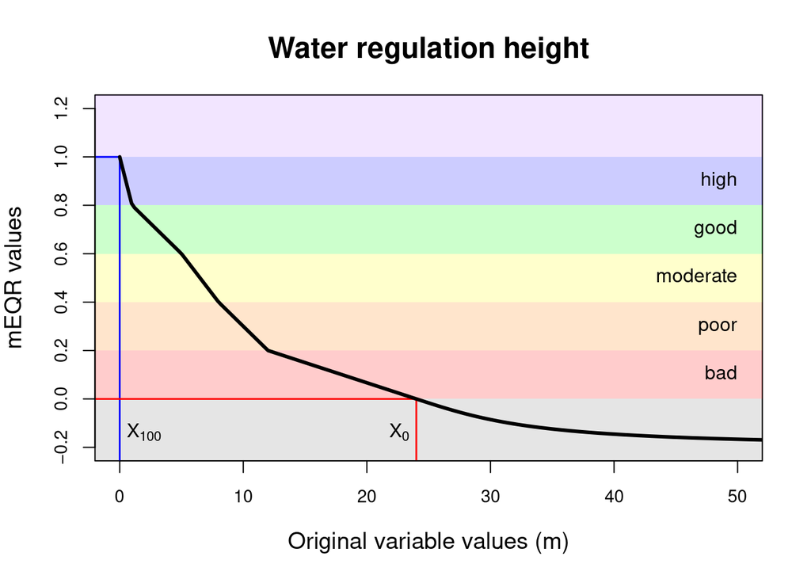

Scaling and transformation from variable measurements to mEQR values.

```r
xlim <- c(0, 50)
xaxis <- seq(0, 50, 10)
yaxis <- seq(-0.2, 1.2, 0.2)
x <- seq(min(klassegrenser), max(klassegrenser), le = 1000)
y <- mEQR(x, klassegrenser)
forklar <- "Original variable values (m)"
plot(x, y, ty = "l", main = "Water regulation height",
     xlim = xlim,         xaxs = "r", xaxt = "n", xlab = forklar,
     ylim = c(-0.2, 1.2), yaxs = "r", yaxt = "n", ylab = "mEQR values",
     cex.main = 1.5, cex.lab = 1.2)
rect(xlim[1]-144,-0.4, xlim[2]+144, 0.0, col = rgb(0.0, 0.0, 0.0, 0.1), border = NA)
rect(xlim[1]-144, 0.0, xlim[2]+144, 0.2, col = rgb(1.0, 0.0, 0.0, 0.2), border = NA)
rect(xlim[1]-144, 0.2, xlim[2]+144, 0.4, col = rgb(1.0, 0.5, 0.0, 0.2), border = NA)
rect(xlim[1]-144, 0.4, xlim[2]+144, 0.6, col = rgb(1.0, 1.0, 0.0, 0.2), border = NA)
rect(xlim[1]-144, 0.6, xlim[2]+144, 0.8, col = rgb(0.0, 1.0, 0.0, 0.2), border = NA)
rect(xlim[1]-144, 0.8, xlim[2]+144, 1.0, col = rgb(0.0, 0.0, 1.0, 0.2), border = NA)
rect(xlim[1]-144, 1.0, xlim[2]+144, 1.4, col = rgb(0.5, 0.0, 1.0, 0.1), border = NA)
lines(c(xlim[1] - 144,    klassegrenser[7]), c(+1, 1), lwd = 1.5, col = "blue")
lines(c(klassegrenser[7], klassegrenser[7]), c(-1, 1), lwd = 1.5, col = "blue")
lines(c(xlim[1] - 144,    klassegrenser[2]), c(+0, 0), lwd = 1.5, col = "red")
lines(c(klassegrenser[2], klassegrenser[2]), c(-1, 0), lwd = 1.5, col = "red")
lines(x, y, lwd = 3)
axis(1, xaxis, erstatt(xaxis, "-", "−"), cex.axis = 0.9)
axis(2, yaxis, c("−0.2", "0.0", 0.2, 0.4, 0.6, 0.8, "1.0", 1.2), cex.axis = 0.9)
text(xlim[2], seq(0.1, 0.9, 0.2), c("bad", "poor", "moderate", "good", "high"),
     pos = 2, offset = 0)
rf <- klassegrenser[7] > klassegrenser[2]
text(klassegrenser[2], -0.15, expression(X[0]),   pos=ifelse(rf, 4, 2), offset=0.3)
text(klassegrenser[7], -0.15, expression(X[100]), pos=ifelse(rf, 2, 4), offset=0.3)
```

Note that variable values may be substantially poorer (larger) than X<sub>0</sub> (red line). An asymptotic transformation is used for X > X<sub>0</sub> in order to keep mEQR values above −0.2.

### 9.4 Estimating the indicator values and their uncertainty

The transformation shown above is now applied to the (actual and simulated) regulation heights. In a final step, quantiles of the nEQR values are estimated for the different regions of Norway and different years.

```r
for (i in which(regh[, 1]  > 0)) regh[i, ] <- mEQR(regh[i, ], klassegrenser)
regh[which(regh[, 1] == 0), ] <- 1 # mEQR(0, klassegrenser) = 1

QNTL <- c(0.025, 0.25, 0.5, 0.75, 0.975)
years <- 1890:2024

regions <- matrix(0, 6, length(QNTL), dimnames = list(c("WholeCountry", "Østlandet",
                    "Sørlandet", "Vestlandet", "Midt-Norge", "Nord-Norge"),
                    "Q" %+% QNTL))
regions["WholeCountry",] <- quantile(apply(regh, 2, weighted.mean, nve$areal), QNTL)
for (L in rownames(regions)[-1]) {
  w <- which(nve$ldel == substr(L, 1, 1))
  regions[L, ] <- quantile(apply(regh[w, ], 2, weighted.mean, nve$areal[w]), QNTL)
}

figure <- matrix(0, length(QNTL), length(years),
                 dimnames=list("Q" %+% QNTL, "Y" %+% years))
nve$areal[is.na(nve$areal)] <- 0
w <- which(nve$regh < 0.001)
nve1 <- nve[1, ]
nve1$areal <- sum(nve$areal[w])
nve1$drift <- 0
nve <- nve[-w, ]
nve <- rbind(nve1, nve)
regh <- regh[-w, ]
regh <- rbind(rep(1, nsim), regh)
sink(tempfile())
gc(verbose = FALSE)
sink()
for (j in rev(years)) {
  w <- which(nve$drift >= j + 1)
  if (length(w)) {
    nve$areal[1] <- nve$areal[1] + sum(nve$areal[w])
    nve  <-  nve[-w, ]
    regh <- regh[-w, ]
  }
  figure[, "Y" %+% j] <- quantile(apply(regh, 2, weighted.mean, nve$areal), QNTL)
}
```

### 9.5 Summary of the output

The estimates and their confidence intervals may be summarised as tables …

```r
print(regions)
```

```
                Q0.025     Q0.25      Q0.5     Q0.75    Q0.975
WholeCountry 0.7936073 0.7959804 0.7973764 0.7989285 0.8024432
Østlandet    0.8028208 0.8054830 0.8069999 0.8083815 0.8107919
Sørlandet    0.7391590 0.7420142 0.7431096 0.7440622 0.7459730
Vestlandet   0.7218594 0.7310659 0.7337801 0.7355270 0.7391470
Midt-Norge   0.7817815 0.7873851 0.7902515 0.7934304 0.8000512
Nord-Norge   0.8353161 0.8430461 0.8462623 0.8500125 0.8608552
```

… or as figures.

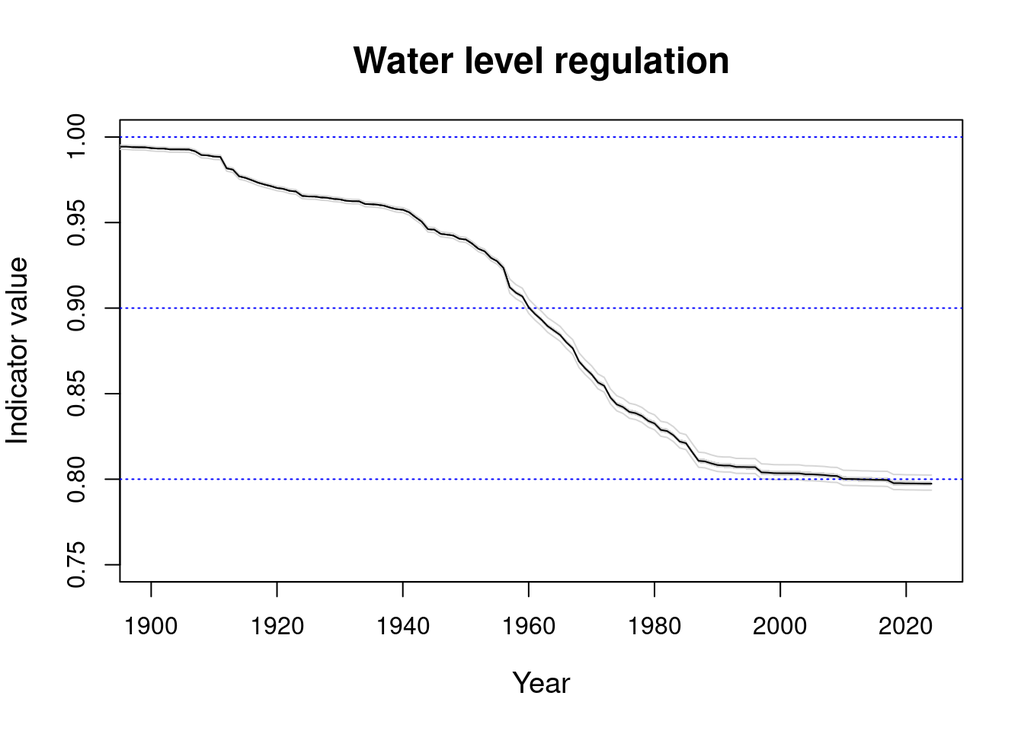

Changes in the national indicator value for water level regulation from 1900 to 2024. The black line is the best estimate (median); the interquartile range is shown as a grey area (barely visible behind the black line); and 95% confidence intervals are shown as thin grey lines.

```r
plot(years, figure["Q0.5", ], ty="l", xlim = c(1900, 2024), ylim=c(0.75, 1),
     xlab = "Year", ylab = "Indicator value", main = "Water level regulation",
     cex.main = 1.5, cex.lab = 1.2)
polygon(c(years, rev(years)), c(figure["Q0.25", ], rev(figure["Q0.75", ])),
        border = NA, col = grey(0.84))
lines(years, figure["Q0.025", ], col = grey(0.84))
lines(years, figure["Q0.975", ], col = grey(0.84))
abline(h = c(1, 0.9, 0.8), col = "blue", lty = 3)
lines(years, figure["Q0.5", ], lwd = 1)
```

## 10. Results

As the scaling function used is non-linear, aggregated averages of *unscaled* values (*variable* values sensu SEEA EA) are not informative. Therefore, this indicator is reported in terms of *scaled* values only (nEQR sensu WFD; *indicator* values sensu SEEA EA).

The results are here tabulated (a) for the whole country and different years, and (b) for regions in 2024. These estimates are based on 10,000 simulations and may therefore differ somewhat from the ones above.

Water level regulation indicator values for Norwegian lakes in different years

| Year | Best estimate | Lower quartile | Upper quartile |
| --- | --- | --- | --- |
| 2024 | 0.797 | 0.796 | 0.799 |
| 1994 | 0.807 | 0.806 | 0.809 |
| 1964 | 0.887 | 0.886 | 0.889 |
| 1934 | 0.961 | 0.960 | 0.961 |
| 1904 | 0.993 | 0.992 | 0.993 |

Water level regulation indicator values for lakes in regions of Norway in 2024

| Region | Best estimate | Lower quartile | Upper quartile |
| --- | --- | --- | --- |
| Østlandet | 0.807 | 0.806 | 0.808 |
| Sørlandet | 0.743 | 0.742 | 0.744 |
| Vestlandet | 0.734 | 0.731 | 0.736 |
| Midt-Norge | 0.790 | 0.787 | 0.794 |
| Nord-Norge | 0.847 | 0.843 | 0.851 |